# Unpacking the Tidyverse - ggplot2

### Geometries

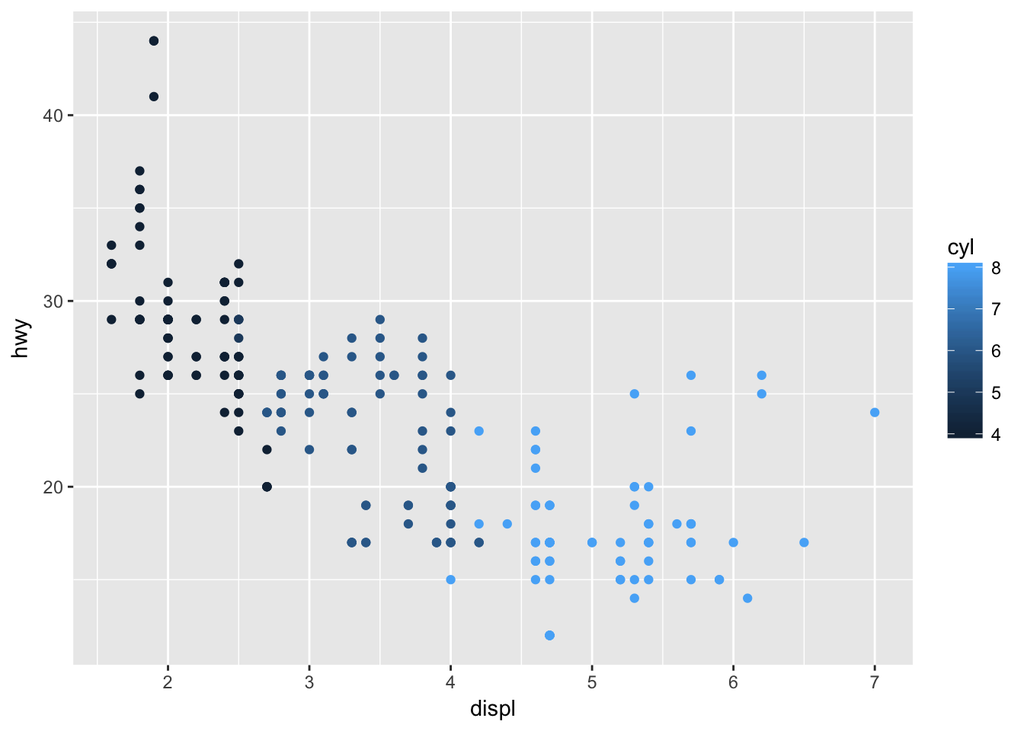

```r
ggplot(mpg) +
  geom_point(mapping = aes(x = displ, y = hwy, color = cyl))
```

Plot geometries are the most important parameter, and the only parameter other than `ggplot()` that must be defined in every single visualization. There are hundreds of geometries avaliable for your use, courtisy of the R community; check out http://www.ggplot2-exts.org/ for more information. Here’s a list of the handful of geometries, mappings, and aestetics that I use most often.

##### Geometries

- **geom_density( )** - 1 variable gaussian distribution
- **geom_point( )** - 2, 3, or 4 variable scatterplot
- **geom_smooth( )** - 2 or 3 variable line plot
- **geom_bar(stat=“identity”)** - 2 or 3 variable bar plot
- **geom_hex( )** - 2 variable distribution
- **geom_tile( )** - 3 variable tile plot
- **geom_map( )** - 2, 3, or 4 variable geospatial

##### Mappings

- **aes( x = )** - x-axis location
- **aes( y = )** - y-axis location
- **aes( …, color = )** - color dependent on variable’s value
- **aes( …, linetype = )** - linetype dependent on variable’s value
- **aes( …, size = )** - size of object dependent on variable’s value

##### Aestetics

- **size =** size of a point, declared by an integer
- **linetype =** 0 (blank), 1 (solid), 1 (dashed), 3 (dotted), 4 (dot-dash), 5 (long-dash), 6 (two-dash)
- **weight =** (line thickness) integer
- **color =** (outline) string
- **fill =** (inside) string
- **alpha =** (transparency) double from 0 to 1

### Statistical Transformation

Sometimes you want to visualize a transformed version of the original data. The statistical transformation I use most often is the identity trasformation with geom_bar. There are, however, several other useful transformations.

- **geom_(aes(…), stat = “count”)** - visualise the number of entires in a variable, n()
- **geom_(aes(…), stat = “identity”)** - visuaise the variable, not the count
- **geom_(aes(…), stat = “unique”)** - visualise only unique components of the variable

### Position Adjustment

When geometric data occupies the same space, it is useful to use a position adjustment to better understand the visualisation. I really only find adjusting the positioning of data useful when I’m working with bar charts and scatterplots.

- **geom_point(aes(…), position = “jitter”)** - adds a small amount of noise to better view overlapping points
- **geom_bar(aes(…), position = “dodge”)** - arranges bar elements side-by-side
- **geom_bar(aes(…), position = “fill”)** - arranges bar elements on top of each other, normalizing height

### Coordinate Systems

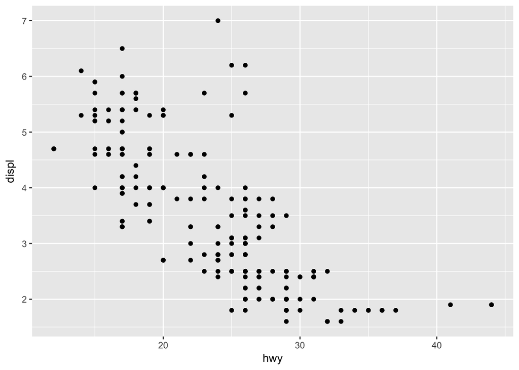

```r
ggplot(mpg) +
  geom_point(mapping = aes(x = displ, y = hwy)) +
  coord_flip()
```

Cartesian coordinates are the go-to for 95% of my visualisations, but the coord_ function does more than call different coordinate systems. Often it’s useful to fix the x-y ratio, or flip the axis of bar charts. When your working with exponential data, you may want to transform an axis to a logarithmic system. These useful functions and many more can be done by the coord_ function.

- **coord_fixed(ratio, xlim, ylim)** - fixing the aspect ratio between x and y
- **coord_flip(xlim, wlim)** - flipping the axes
- **coord_polar(theta, start, direction)** - coverting cartesian to polar coordinates
- **coord_trans(xtrans, ytrans, limx, limy)** - transform cartesian coordiantes, use with log functions
- **coord_map(projection, orientation, xlim, ylim)** - mapproj package projections

### Facets

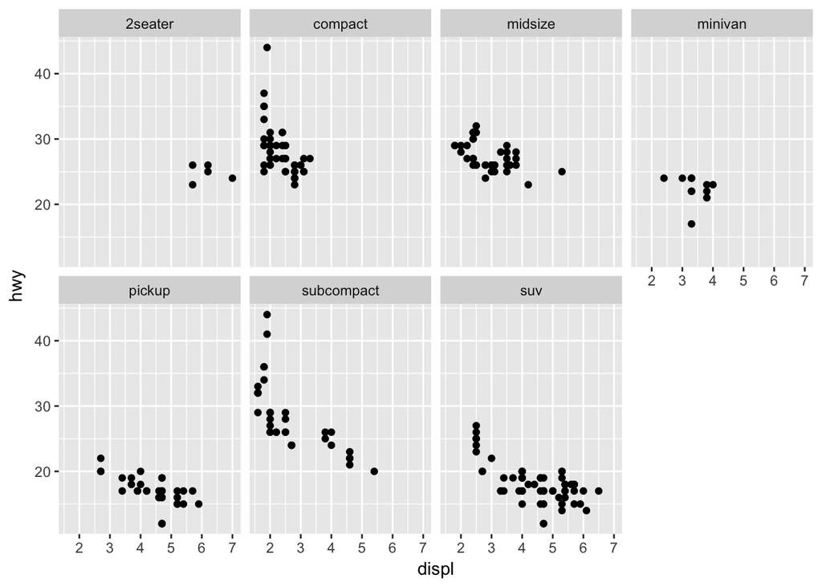

```r
ggplot(data = mpg) +
  geom_point(mapping = aes(x = displ, y = hwy)) +
  facet_wrap(~ class, nrow = 2)
```

I don’t use facets that much; to be honest I find them pretty distracting. If you’re a fan of contrasting minerature plots, you might find these faceting options useful.

- **facet_grid(x ~ y, labeller, scales)** - facets the display into rows and columns based on the two given variables (“.”" placeholder)
- **facet_wrap(~ x, labeller, scales, nrow, ncol)** - wraps facets into a rectangular layout

### Labels

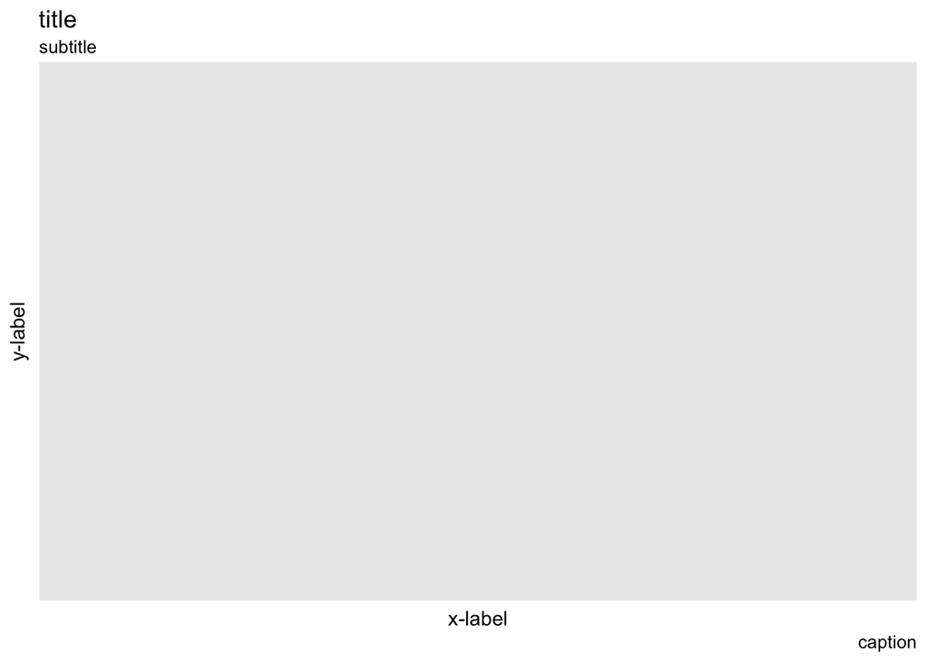

```r
ggplot(mpg) +
  labs(
    title = "title",
    subtitle = "subtitle",
    caption = "caption",
    xlab = "x-label",
    ylab = "y-label"
  )
```

Labels are helpful for properly communicating your visualisation. Including these five labels with your plots can help clarify your topic, variables, and sources.

### Annotations

Annotations are another feature I don’t use too often, but I’ll include them anyways. I think annotating individual observations is a mistake, it clutters the graphic and takes away from the effectiveness of the visualisation. Packages like plotly and shiny do a better job of creating interactive graphics if you want individual labels. If you, however, insist on creating a ggplot with annotations, these might be useful.

- **geom_text(aes(label = “text here”), vjust = , hjust = )** - places a summary annotation within the graphic, according to vjust and hjust
- **geom_hline(yintercept = , size = , color = , linetype)** - creates a horizontal reference line through the plot according to yintercept
- **geom_vline(xintercept = , size =, color =, linetype =)** - creates a verticle reference line through the plot according to xintercept
- **geom_rect(aes(xmin = , xmax = , ymin = , ymax = ))** - creates a rectangle to box in and highlight interesting data
- **geom_segment(aes(x = , y = , xend = , yend = ,) arrow = )** - creates a line segment within the plot, it can be an arrow

### Scales

Scales are automatically set when you create a ggplot, but sometimes it’s useful to alter the color scheme, legend, or axes. The naming sceme for these functions is scale_ followed by the name of the aesthetic then another _, and then the name of the scale.

##### Aestetic Names

- **_x_**
- **_y_**
- **_alpha_**
- **_color_**
- **_fill_**
- **_linetype_**
- **_shape_**
- **_size_**

##### Scale Names

- **_discrete** - maps discrete variables to visual values
- **_continous** - maps continuous variables to visual values
- **_identity** - uses data values as visual values
- **_manual** - values = c( ), maps discrete values to manually chose visual values
- **_gradient** - creates a two color gradient, low - high
- **_gradient2** - creates a diverging two color gradient, positive - negative
- **_gray** -creates a gradient in gray
- **_brewer** - brewer( palette = " “), calls RColorBrewer palettes

### Axes

```r
scale_x_continuous(breaks = seq(0, 10, by = 1), labels = c(1:9, "ten"))
# define breaks by sequence, define labels of breaks

scale_x_discrete(breaks=c("ctrl", "trt1", "trt2"),            # defined tick marks
                 labels=c("Control", "Treat 1", "Treat 2"))   # new names

expand_limits(x = c(0,8), y = c(0,8))                         # expand the limits of the graph to visualise specific values

scale_y_reverse()     # Reverse y-axis direction (zero on top)

element_blank()       # Hiding axis labels

theme(axis.title.x = element_text(face="bold", color="red", size=20),  # change axis labels, font and style
      axis.text.x = element_text(angle=90, vjust=0.5, size=16))        # change tick mark label, font, style

theme(panel.grid.major=element_blank(),  # hiding major gridlines
      panel.grid.minor=element_blank())  # hiding minor gridlines

library(scales)   # changing the y-axis to log 10
scale_y_log10(breaks = trans_breaks("log10", function(x) 10^x),
              labels = trans_format("log10", math_format(10^.x)))
```

Scales can be used to alter axes in ggplot2, it’s a fairly straight forward process. These are some commented examples for fixing common behavioral issues you may have with your axes.

### Legends

```r
theme(legend.position = "left")    # legend to the left of plot
theme(legend.position = "top")     # legend above plot
theme(legend.position = "bottom")  # legend below plot
theme(legend.position = "right")   # the default
theme(legend.position = "none")    # no legend will be generated

geom_point(aes(...), show.legend=FALSE) # don't include this geom in the legend

theme(legend.title = element_blank()) # hides the legends title

# changing the order of items in your legend, scale_ function is dependent upon the type of plot
scale_fill_discrete(breaks=(c("item1", "item2", "item3")))

# simply reverse the current item display in thelegend
scale_fill_discrete(guide = guide_legend(reverse=TRUE))

# manually alter color, break, label, and name of legend items.
scale_fill_manual(values=c("#999999", "#E69F00", "#56B4E9"),
                  name="Experimental\nCondition",
                  breaks=c("ctrl", "trt1", "trt2"),
                  labels=c("Control", "Treatment 1", "Treatment 2"))
```

Legends can be a bit harder to wrangle than axes. Heere are examples to several common problems I have with legends.

### Colors

Some of my favorite preset colors include

- thistle
- slateblue2
- orchid
- midnightblue
- deepskyblue
- lightslateblue

The RColorBrewer package also has some great color palettes.

```r
RColorBrewer::display.brewer.all()
```

[output not shown]

### Themes

Sometimes you don’t want to go through the effort of creating your own theme, so ggplot2 has some built in. Here are four basic themes that are excellent for exploratory analysis or creating a solid foundation to build off.

- **theme_bw()** - A while background with gridlines
- **theme_grey()** - the default theme
- **theme_classic()** - A white background with no gridlines
- **theme_minimal()** - mystery theme, check it out!

### Conclusions

For more useful resources, including advanced ggplot2 techniques, check out these links:

R Graphics ggplot2 Cookbook - http://www.cookbook-r.com/Graphs/  
Top 50 Visualizations - http://r-statistics.co/Top50-Ggplot2-Visualizations-MasterList-R-Code.html  
R Studio’s ggplot2 Cheat Sheet - https://www.rstudio.com/wp-content/uploads/2015/03/ggplot2-cheatsheet.pdf  
Hadley’s ggplot2 book (amazon) - https://www.amazon.com/dp/331924275X/ref=cm_sw_su_dp

Thanks for reading,  
- Fisher